# Machine Learning with the Experts: School Budgets

- William Surles
- 2017-12-04
- Datacamp course
- https://www.datacamp.com/courses/machine-learning-with-the-experts-school-budgets

## Whats Covered

**Exploring the raw data**

- Introducing the challenge
- Exploring the data
- Looking at the datatypes
- How do we measure success?

**Creating a simple first model**

- It's time to build a model
- Making predictions
- A very brief introduction to NLP
- Representing text numerically

**Improving your model**

- Pipelines, feature & text preprocessing
- Text features and feature unions
- Choosing a classification model

**Learning from the experts**

- Learning from the expert: processing
- Learning from the expert: a stats trick
- Learning from the expert: a computational trick and the winning model
- Next steps and the social impact of your work

## Additional Resources

- [Box Plots for Education Competition on DrivenData](https://www.drivendata.org/competitions/46/box-plots-for-education-reboot/)
  - Get the data and try the models for real.

## Libraries and Data

```python
import numpy as np
import pandas as pd
import matplotlib.pyplot as plt
```

# Exploring the raw data

## Introducing the challenge

- Learn from the expert who won DrivenData's challenge
  - Natural language processing
  - Feature engineering
  - Efficiency boosting hashing tricks
- Use data to have a social impact
- Budgets for schools are uge, complex, and not standardized
  - Hundreds of hous each year are spent manually labelling
- Goal: Build a machine learning algorithm that can automate the process
- Budget data
  - Line-item: "Algebra books for 8th grade students"
  - Labels: "Textbooks", "math", "Middle school"
- This is a supervised learning problem
  - We want to build an algorithm that can correctly label categories based on a set of labeled data
  - If we had no labels and just wanted to see what items go together, it would be unsupervised
- Over 100 target variables
  - This is a classification problem. We want to predict a label
  - If we tried to predict a value it would be a regression problem
- We don't want our algorithm to just label the data
  - We want to say we are 60% sure its textbooks, 30% office supplies, etc.

### What category of problem is this?

### What is the goal of the algorithm?

## Exploring the data

### Loading the data

```python
file = 'data/TrainingData.csv'
df = pd.read_csv(file, index_col = 0)
df.head()
```

|  | Function | Use | Sharing | Reporting | Student_Type | Position_Type | Object_Type | Pre_K | Operating_Status | Object_Description | ... | Sub_Object_Description | Location_Description | FTE | Function_Description | Facility_or_Department | Position_Extra | Total | Program_Description | Fund_Description | Text_1 |
| --- | --- | --- | --- | --- | --- | --- | --- | --- | --- | --- | --- | --- | --- | --- | --- | --- | --- | --- | --- | --- | --- |
| 134338 | Teacher Compensation | Instruction | School Reported | School | NO_LABEL | Teacher | NO_LABEL | NO_LABEL | PreK-12 Operating | NaN | ... | NaN | NaN | 1.0 | NaN | NaN | KINDERGARTEN | 50471.810 | KINDERGARTEN | General Fund | NaN |
| 206341 | NO_LABEL | NO_LABEL | NO_LABEL | NO_LABEL | NO_LABEL | NO_LABEL | NO_LABEL | NO_LABEL | Non-Operating | CONTRACTOR SERVICES | ... | NaN | NaN | NaN | RGN GOB | NaN | UNDESIGNATED | 3477.860 | BUILDING IMPROVEMENT SERVICES | NaN | BUILDING IMPROVEMENT SERVICES |
| 326408 | Teacher Compensation | Instruction | School Reported | School | Unspecified | Teacher | Base Salary/Compensation | Non PreK | PreK-12 Operating | Personal Services - Teachers | ... | NaN | NaN | 1.0 | NaN | NaN | TEACHER | 62237.130 | Instruction - Regular | General Purpose School | NaN |
| 364634 | Substitute Compensation | Instruction | School Reported | School | Unspecified | Substitute | Benefits | NO_LABEL | PreK-12 Operating | EMPLOYEE BENEFITS | ... | NaN | NaN | NaN | UNALLOC BUDGETS/SCHOOLS | NaN | PROFESSIONAL-INSTRUCTIONAL | 22.300 | GENERAL MIDDLE/JUNIOR HIGH SCH | NaN | REGULAR INSTRUCTION |
| 47683 | Substitute Compensation | Instruction | School Reported | School | Unspecified | Teacher | Substitute Compensation | NO_LABEL | PreK-12 Operating | TEACHER COVERAGE FOR TEACHER | ... | NaN | NaN | NaN | NON-PROJECT | NaN | PROFESSIONAL-INSTRUCTIONAL | 54.166 | GENERAL HIGH SCHOOL EDUCATION | NaN | REGULAR INSTRUCTION |

5 rows × 25 columns

```python
df.info()
```

```
<class 'pandas.core.frame.DataFrame'>
Int64Index: 400277 entries, 134338 to 415831
Data columns (total 25 columns):
Function                  400277 non-null object
Use                       400277 non-null object
Sharing                   400277 non-null object
Reporting                 400277 non-null object
Student_Type              400277 non-null object
Position_Type             400277 non-null object
Object_Type               400277 non-null object
Pre_K                     400277 non-null object
Operating_Status          400277 non-null object
Object_Description        375493 non-null object
Text_2                    88217 non-null object
SubFund_Description       306855 non-null object
Job_Title_Description     292743 non-null object
Text_3                    179964 non-null object
Text_4                    53746 non-null object
Sub_Object_Description    91603 non-null object
Location_Description      162054 non-null object
FTE                       126071 non-null float64
Function_Description      342195 non-null object
Facility_or_Department    53886 non-null object
Position_Extra            264764 non-null object
Total                     395722 non-null float64
Program_Description       304660 non-null object
Fund_Description          202877 non-null object
Text_1                    292285 non-null object
dtypes: float64(2), object(23)
memory usage: 79.4+ MB
```

```python
df.describe()
```

|  | FTE | Total |
| --- | --- | --- |
| count | 126071.000000 | 3.957220e+05 |
| mean | 0.426794 | 1.310586e+04 |
| std | 0.573576 | 3.682254e+05 |
| min | -0.087551 | -8.746631e+07 |
| 25% | 0.000792 | 7.379770e+01 |
| 50% | 0.130927 | 4.612300e+02 |
| 75% | 1.000000 | 3.652662e+03 |
| max | 46.800000 | 1.297000e+08 |

### Summarizing the data

- For some reason, there is a vary large value under FTE that skews the data. It is around 48 I believe.

```python
df2 = df[df.FTE < 2]
```

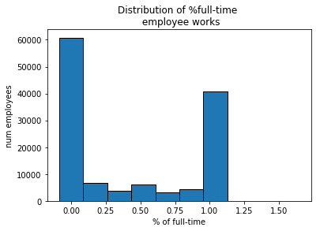

```python
# Create the histogram
plt.hist(df2.FTE.dropna(), edgecolor = 'k')

# Add title and labels
plt.title('Distribution of %full-time \n employee works')
plt.xlabel('% of full-time')
plt.ylabel('num employees')

# Display the histogram
plt.show()
```

## Looking at the datatypes

#### Encode labels as categories

- ML algorithms work on numbers, not strings
  - Need a numeric representation of these strings
- Strings can be slow compared to numbers
- In pandas, 'category' dtype encodes categorical data numerically
  - Can speed up code

### Exploring datatypes in pandas

- It's always good to know what datatypes you're working with, especially when the inefficient pandas type object may be involved.
  - Towards that end, let's explore what we have.

```python
df.dtypes.value_counts()
```

```
object     23
float64     2
dtype: int64
```

### Encode the labels as categorical variables

- There are 9 columns of labels in the dataset. Each of these columns is a category that has many possible values it can take).

```python
labels = ['Function', 'Use', 'Sharing', 'Reporting', 'Student_Type',
 'Position_Type', 'Object_Type', 'Pre_K', 'Operating_Status']
```

```python
df[labels].dtypes
```

```
Function            object
Use                 object
Sharing             object
Reporting           object
Student_Type        object
Position_Type       object
Object_Type         object
Pre_K               object
Operating_Status    object
dtype: object
```

```python
# Define the lambda function: categorize_label
categorize_label = lambda x: x.astype('category')

# Convert df[labels] to a categorical type
df[labels] = df[labels].apply(categorize_label, axis = 0)

# Print the converted dtypes
print(df[labels].dtypes)
```

```
Function            category
Use                 category
Sharing             category
Reporting           category
Student_Type        category
Position_Type       category
Object_Type         category
Pre_K               category
Operating_Status    category
dtype: object
```

### Counting unique labels

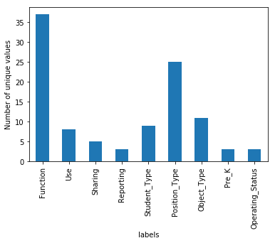

```python
# Calculate number of unique values for each label: num_unique_labels
num_unique_labels = df[labels].apply(pd.Series.nunique)

# Plot number of unique values for each label
num_unique_labels.plot(kind = 'bar')

# Label the axes
plt.xlabel('labels')
plt.ylabel('Number of unique values')

# Display the plot
plt.show()
```

## How do we measure success?

#### How do we measure success?

- Accuracy can be misleading when classes are imbalanced
  - Legitimate email: 99%, Spam: 1%
  - Model that never predicts spam will be 99% accurate
  - But this is not useful at all
- Metric used in the problem: log loss
  - It is a loss funciton
  - measure of error
  - Wnat to minimize the error (unlike accuracy)

#### Log loss binary classification

- Log loss binary classification
  - Actual value: y = {1=yes, 0=no}
  - Prediction (probability that the value is 1): p

$$ logloss = -\frac{1}{N}\sum_{i=1}^{N}(y_i log(p_i) + (1 - y_i)log(1 - p_i)) $$

#### Log loss binary classification: example

$$ logloss_{(N=1)} = ylog(p) + (1 - y)log(1 - p) $$

- True label = 0
- Model confidently predicts 1 (with p = 0.90)
- Log loss =
  - ylog(p) + (1 - y)log(1 - p)
  - 0log(.9) + (1 - 0)log(1 - .9)
  - 0 + log(0.1)
  - 2.30
- Another case with label = 1
- Model predicts 0 (with p = 0.50)
- log loss = 0.69
- better to be less confident than confident and wrong

#### Computing log loss it NumPy

```python
def compute_log_loss(predicted, actual, eps=1e-14):
    """Computes the logarithmic los between predicted and actual when these are 1D arrays.

    :param predicted: The predicted probabilities as floats bwtween 0-1
    :param actual: The actual binary labels. Either 0 or 1.
    :param eps (optional): log(0) is inf, so we need to offset our predicted values slightly by eps from 0 or 1.
    """

    predicted = np.clip(predicted, eps, 1 - eps)
    loss = -1 * np.mean(actual * np.log(predicted) + (1 - actual) * np.log(1 - predicted))

    return loss
```

### Penalizing highly confident wrong answers

```python
## right and fairly confident
compute_log_loss(predicted = 0.85, actual = 1)
```

```
0.16251892949777494
```

```python
## wrong and confident
compute_log_loss(predicted = 0.99, actual = 0)
```

```
4.6051701859880909
```

```python
## wrong and not confident
compute_log_loss(predicted = 0.51, actual = 0)
```

```
0.71334988787746478
```

### Computing log loss with NumPy

```python
actual_labels = np.array([ 1.,  1.,  1.,  1.,  1.,  0.,  0.,  0.,  0.,  0.])
correct_confident = np.array([ 0.95,  0.95,  0.95,  0.95,  0.95,  0.05,  0.05,  0.05,  0.05,  0.05])
correct_not_confident = np.array([ 0.65,  0.65,  0.65,  0.65,  0.65,  0.35,  0.35,  0.35,  0.35,  0.35])
wrong_not_confident = np.array([ 0.35,  0.35,  0.35,  0.35,  0.35,  0.65,  0.65,  0.65,  0.65,  0.65])
wrong_confident = np.array([ 0.05,  0.05,  0.05,  0.05,  0.05,  0.95,  0.95,  0.95,  0.95,  0.95])
```

```python
# Compute and print log loss for 1st case
correct_confident = compute_log_loss(correct_confident, actual_labels)
print("Log loss, correct and confident: {}".format(correct_confident))
```

```
Log loss, correct and confident: 0.05129329438755058
```

```python
# Compute log loss for 2nd case
correct_not_confident = compute_log_loss(correct_not_confident, actual_labels)
print("Log loss, correct and not confident: {}".format(correct_not_confident))
```

```
Log loss, correct and not confident: 0.4307829160924542
```

```python
# Compute and print log loss for 3rd case
wrong_not_confident = compute_log_loss(wrong_not_confident, actual_labels)
print("Log loss, wrong and not confident: {}".format(wrong_not_confident))
```

```
Log loss, wrong and not confident: 1.049822124498678
```

```python
# Compute and print log loss for 4th case
wrong_confident = compute_log_loss(wrong_confident, actual_labels)
print("Log loss, wrong and confident: {}".format(wrong_confident))
```

```
Log loss, wrong and confident: 2.9957322735539904
```

```python
# Compute and print log loss for actual labels
actual_labels = compute_log_loss(actual_labels, actual_labels)
print("Log loss, actual labels: {}".format(actual_labels))
```

```
Log loss, actual labels: 9.99200722162646e-15
```

# Creating a simple first model

## It's time to build a model

#### It's time to build a model

- Always a good appraoch to start with a very simple mondel
- Gives a sense of how challenging the problem is
- Many more things can go wrong in complex models
- How much signal can we pull out using basic methods?
- Train basic model on numeric data only
  - Want to go from raw data to predictions only
- Multi-class logistic regression
  - Train classifier on each label separately and use those to predict
- Format predictions and save to csv
- Compute log loss score

#### Splitting the multi-class dataset

- Recall: Train-test split
  - Will not work here
  - Some of the labels are rare
  - May end up with labels in test set that never appear in training set
- Solution: StratifiedShuffleSplit
  - But only works with a single target variable
  - We have many target variables
  - `multilabel_train_test_split()` function will be provided for use to split properly

#### Training the model

- One vs Rest Classifier:
  - Treats each column of y independently
  - Fits a separate classifier for each of the columns

#### Multilabel train test split

- This function will ensue that atleast `min_count` examples of each label appear in each split
- This is provided by Peter Bull, the instructor, [here](https://github.com/drivendataorg/box-plots-sklearn/blob/master/src/data/multilabel.py)

```python
def multilabel_sample(y, size=1000, min_count=5, seed=None):
    """ Takes a matrix of binary labels `y` and returns
        the indices for a sample of size `size` if
        `size` > 1 or `size` * len(y) if size =< 1.
        The sample is guaranteed to have > `min_count` of
        each label.
    """
    try:
        if (np.unique(y).astype(int) != np.array([0, 1])).all():
            raise ValueError()
    except (TypeError, ValueError):
        raise ValueError('multilabel_sample only works with binary indicator matrices')

    if (y.sum(axis=0) < min_count).any():
        raise ValueError('Some classes do not have enough examples. Change min_count if necessary.')

    if size <= 1:
        size = np.floor(y.shape[0] * size)

    if y.shape[1] * min_count > size:
        msg = "Size less than number of columns * min_count, returning {} items instead of {}."
        warn(msg.format(y.shape[1] * min_count, size))
        size = y.shape[1] * min_count

    rng = np.random.RandomState(seed if seed is not None else np.random.randint(1))

    if isinstance(y, pd.DataFrame):
        choices = y.index
        y = y.values
    else:
        choices = np.arange(y.shape[0])

    sample_idxs = np.array([], dtype=choices.dtype)

    # first, guarantee > min_count of each label
    for j in range(y.shape[1]):
        label_choices = choices[y[:, j] == 1]
        label_idxs_sampled = rng.choice(label_choices, size=min_count, replace=False)
        sample_idxs = np.concatenate([label_idxs_sampled, sample_idxs])

    sample_idxs = np.unique(sample_idxs)

    # now that we have at least min_count of each, we can just random sample
    sample_count = int(size - sample_idxs.shape[0])

    # get sample_count indices from remaining choices
    remaining_choices = np.setdiff1d(choices, sample_idxs)
    remaining_sampled = rng.choice(remaining_choices,
                                   size=sample_count,
                                   replace=False)

    return np.concatenate([sample_idxs, remaining_sampled])


def multilabel_sample_dataframe(df, labels, size, min_count=5, seed=None):
    """ Takes a dataframe `df` and returns a sample of size `size` where all
        classes in the binary matrix `labels` are represented at
        least `min_count` times.
    """
    idxs = multilabel_sample(labels, size=size, min_count=min_count, seed=seed)
    return df.loc[idxs]


def multilabel_train_test_split(X, Y, size, min_count=5, seed=None):
    """ Takes a features matrix `X` and a label matrix `Y` and
        returns (X_train, X_test, Y_train, Y_test) where all
        classes in Y are represented at least `min_count` times.
    """
    index = Y.index if isinstance(Y, pd.DataFrame) else np.arange(Y.shape[0])

    test_set_idxs = multilabel_sample(Y, size=size, min_count=min_count, seed=seed)
    train_set_idxs = np.setdiff1d(index, test_set_idxs)

    test_set_mask = index.isin(test_set_idxs)
    train_set_mask = ~test_set_mask

    return (X[train_set_mask], X[test_set_mask], Y[train_set_mask], Y[test_set_mask])
```

### Setting up a train-test split in scikit-learn

```python
numeric_columns = ['FTE', 'Total']
```

```python
# Create the new DataFrame: numeric_data_only
numeric_data_only = df[numeric_columns].fillna(-1000)

numeric_data_only.head()
```

|  | FTE | Total |
| --- | --- | --- |
| 134338 | 1.0 | 50471.810 |
| 206341 | -1000.0 | 3477.860 |
| 326408 | 1.0 | 62237.130 |
| 364634 | -1000.0 | 22.300 |
| 47683 | -1000.0 | 54.166 |

```python
# Get labels and convert to dummy variables: label_dummies
label_dummies = pd.get_dummies(df[labels])

label_dummies.head()
```

|  | Function_Aides Compensation | Function_Career & Academic Counseling | Function_Communications | Function_Curriculum Development | Function_Data Processing & Information Services | Function_Development & Fundraising | Function_Enrichment | Function_Extended Time & Tutoring | Function_Facilities & Maintenance | Function_Facilities Planning | ... | Object_Type_Rent/Utilities | Object_Type_Substitute Compensation | Object_Type_Supplies/Materials | Object_Type_Travel & Conferences | Pre_K_NO_LABEL | Pre_K_Non PreK | Pre_K_PreK | Operating_Status_Non-Operating | Operating_Status_Operating, Not PreK-12 | Operating_Status_PreK-12 Operating |
| --- | --- | --- | --- | --- | --- | --- | --- | --- | --- | --- | --- | --- | --- | --- | --- | --- | --- | --- | --- | --- | --- |
| 134338 | 0 | 0 | 0 | 0 | 0 | 0 | 0 | 0 | 0 | 0 | ... | 0 | 0 | 0 | 0 | 1 | 0 | 0 | 0 | 0 | 1 |
| 206341 | 0 | 0 | 0 | 0 | 0 | 0 | 0 | 0 | 0 | 0 | ... | 0 | 0 | 0 | 0 | 1 | 0 | 0 | 1 | 0 | 0 |
| 326408 | 0 | 0 | 0 | 0 | 0 | 0 | 0 | 0 | 0 | 0 | ... | 0 | 0 | 0 | 0 | 0 | 1 | 0 | 0 | 0 | 1 |
| 364634 | 0 | 0 | 0 | 0 | 0 | 0 | 0 | 0 | 0 | 0 | ... | 0 | 0 | 0 | 0 | 1 | 0 | 0 | 0 | 0 | 1 |
| 47683 | 0 | 0 | 0 | 0 | 0 | 0 | 0 | 0 | 0 | 0 | ... | 0 | 1 | 0 | 0 | 1 | 0 | 0 | 0 | 0 | 1 |

5 rows × 104 columns

```python
# Create training and test sets
X_train, X_test, y_train, y_test = multilabel_train_test_split(
    numeric_data_only, label_dummies,
    size=0.2,
    seed=123)

# Print the info
print("X_train info:")
print(X_train.info())
print("\nX_test info:")
print(X_test.info())
print("\ny_train info:")
print(y_train.info())
print("\ny_test info:")
print(y_test.info())
```

```
X_train info:
<class 'pandas.core.frame.DataFrame'>
Int64Index: 320222 entries, 134338 to 415831
Data columns (total 2 columns):
FTE      320222 non-null float64
Total    320222 non-null float64
dtypes: float64(2)
memory usage: 7.3 MB
None

X_test info:
<class 'pandas.core.frame.DataFrame'>
Int64Index: 80055 entries, 206341 to 72072
Data columns (total 2 columns):
FTE      80055 non-null float64
Total    80055 non-null float64
dtypes: float64(2)
memory usage: 1.8 MB
None

y_train info:
<class 'pandas.core.frame.DataFrame'>
Int64Index: 320222 entries, 134338 to 415831
Columns: 104 entries, Function_Aides Compensation to Operating_Status_PreK-12 Operating
dtypes: uint8(104)
memory usage: 34.2 MB
None

y_test info:
<class 'pandas.core.frame.DataFrame'>
Int64Index: 80055 entries, 206341 to 72072
Columns: 104 entries, Function_Aides Compensation to Operating_Status_PreK-12 Operating
dtypes: uint8(104)
memory usage: 8.6 MB
None
```

### Training a model

```python
# Import classifiers
from sklearn.linear_model import LogisticRegression
from sklearn.multiclass import OneVsRestClassifier

# Instantiate the classifier: clf
clf = OneVsRestClassifier(LogisticRegression())

# Fit the classifier to the training data
clf.fit(X_train, y_train)
```

```
OneVsRestClassifier(estimator=LogisticRegression(C=1.0, class_weight=None, dual=False, fit_intercept=True,
          intercept_scaling=1, max_iter=100, multi_class='ovr', n_jobs=1,
          penalty='l2', random_state=None, solver='liblinear', tol=0.0001,
          verbose=0, warm_start=False),
          n_jobs=1)
```

```python
# Print the accuracy
print("Accuracy: {}".format(clf.score(X_test, y_test)))
```

```
Accuracy: 0.0
```

#### Let me use the log loss scoring

```python
test_predictions = pd.DataFrame(
    data = clf.predict_proba(X_test[numeric_columns].fillna(-1000)),
    columns = pd.get_dummies(df[labels]).columns,
    index = y_test.index,)

test_predictions.head()
```

|  | Function_Aides Compensation | Function_Career & Academic Counseling | Function_Communications | Function_Curriculum Development | Function_Data Processing & Information Services | Function_Development & Fundraising | Function_Enrichment | Function_Extended Time & Tutoring | Function_Facilities & Maintenance | Function_Facilities Planning | ... | Object_Type_Rent/Utilities | Object_Type_Substitute Compensation | Object_Type_Supplies/Materials | Object_Type_Travel & Conferences | Pre_K_NO_LABEL | Pre_K_Non PreK | Pre_K_PreK | Operating_Status_Non-Operating | Operating_Status_Operating, Not PreK-12 | Operating_Status_PreK-12 Operating |
| --- | --- | --- | --- | --- | --- | --- | --- | --- | --- | --- | --- | --- | --- | --- | --- | --- | --- | --- | --- | --- | --- |
| 206341 | 0.035848 | 0.006466 | 0.000830 | 0.023919 | 0.008916 | 0.000221 | 0.032078 | 0.024406 | 0.052102 | 0.000048 | ... | 0.010728 | 0.036952 | 0.116162 | 0.017361 | 0.831233 | 0.141041 | 0.027751 | 0.169607 | 0.019930 | 0.810552 |
| 275539 | 0.035883 | 0.006465 | 0.000830 | 0.023923 | 0.008915 | 0.000221 | 0.032085 | 0.024410 | 0.052119 | 0.000048 | ... | 0.010726 | 0.037619 | 0.116387 | 0.017363 | 0.831181 | 0.141101 | 0.027762 | 0.169575 | 0.019932 | 0.810608 |
| 330504 | 0.035886 | 0.006465 | 0.000830 | 0.023923 | 0.008915 | 0.000221 | 0.032085 | 0.024411 | 0.052120 | 0.000048 | ... | 0.010726 | 0.037663 | 0.116402 | 0.017364 | 0.831177 | 0.141105 | 0.027763 | 0.169573 | 0.019932 | 0.810612 |
| 18698 | 0.035885 | 0.006465 | 0.000830 | 0.023923 | 0.008915 | 0.000221 | 0.032085 | 0.024410 | 0.052120 | 0.000048 | ... | 0.010726 | 0.037647 | 0.116397 | 0.017364 | 0.831178 | 0.141103 | 0.027763 | 0.169574 | 0.019932 | 0.810610 |
| 291539 | 0.122566 | 0.009044 | 0.001524 | 0.028673 | 0.016024 | 0.017081 | 0.043998 | 0.031789 | 0.114389 | 0.017294 | ... | 0.005603 | 0.175223 | 0.139555 | 0.016081 | 0.500542 | 0.473756 | 0.099110 | 0.095647 | 0.051075 | 0.928649 |

5 rows × 104 columns

```python
y_test.head()
```

|  | Function_Aides Compensation | Function_Career & Academic Counseling | Function_Communications | Function_Curriculum Development | Function_Data Processing & Information Services | Function_Development & Fundraising | Function_Enrichment | Function_Extended Time & Tutoring | Function_Facilities & Maintenance | Function_Facilities Planning | ... | Object_Type_Rent/Utilities | Object_Type_Substitute Compensation | Object_Type_Supplies/Materials | Object_Type_Travel & Conferences | Pre_K_NO_LABEL | Pre_K_Non PreK | Pre_K_PreK | Operating_Status_Non-Operating | Operating_Status_Operating, Not PreK-12 | Operating_Status_PreK-12 Operating |
| --- | --- | --- | --- | --- | --- | --- | --- | --- | --- | --- | --- | --- | --- | --- | --- | --- | --- | --- | --- | --- | --- |
| 206341 | 0 | 0 | 0 | 0 | 0 | 0 | 0 | 0 | 0 | 0 | ... | 0 | 0 | 0 | 0 | 1 | 0 | 0 | 1 | 0 | 0 |
| 275539 | 0 | 0 | 0 | 0 | 0 | 0 | 0 | 0 | 0 | 0 | ... | 0 | 0 | 0 | 0 | 1 | 0 | 0 | 0 | 0 | 1 |
| 330504 | 0 | 0 | 0 | 0 | 0 | 0 | 0 | 0 | 0 | 0 | ... | 0 | 0 | 1 | 0 | 1 | 0 | 0 | 0 | 0 | 1 |
| 18698 | 0 | 0 | 0 | 0 | 0 | 0 | 0 | 0 | 0 | 0 | ... | 0 | 1 | 0 | 0 | 0 | 1 | 0 | 0 | 0 | 1 |
| 291539 | 0 | 0 | 0 | 0 | 0 | 0 | 0 | 0 | 0 | 0 | ... | 0 | 0 | 0 | 0 | 1 | 0 | 0 | 0 | 0 | 1 |

5 rows × 104 columns

```python
# make sure that format is correct
assert (test_predictions.columns == y_test.columns).all()
assert (test_predictions.index == y_test.index).all()

compute_log_loss(test_predictions.values, y_test.values)
```

```
0.18192283047299601
```

- Well that seems suprisingly good.
- I can see how some of the labels are predicted correclty in just the top of the data frames
- But the best score on the scoreboard of the competition is 0.3665
  - Something must be different there. I know its using data we don't have here.

## Making predictions

#### Predicting on holdout data

- If `.predict()` was used instead:
  - output would be 0 or 1
  - log loss penalizes being confident and wrong
  - worse performance compared to `.predict_proba()`
- All formatting can be done with the pandas `to_csv` funciton

### Use your model to predict values on holdout data

#### Load the holdout data: holdout

- I needed to scrape this from the class.
- They have their own set of holdout data that they use
- And later we will compare this to the holdout labels they use
- I have the test dataset from the competition by the labels for the test data are hidden.
  - This is what the competition uses to score the models on the leaderboard

```python
%run data/HoldoutData.py
```

```python
holdout.head()
```

|  | Object_Description | Program_Description | SubFund_Description | Job_Title_Description | Facility_or_Department | Sub_Object_Description | Location_Description | FTE | Function_Description | Position_Extra | Text_4 | Total | Text_2 | Text_3 | Fund_Description | Text_1 |
| --- | --- | --- | --- | --- | --- | --- | --- | --- | --- | --- | --- | --- | --- | --- | --- | --- |
| 0 | Personal Services - Teachers | Instruction - Regular | NaN | NaN | NaN | NaN | NaN | 0.0 | NaN | TIME CARD CERTIFIEDAddl | Alternative Schools Instruction | 175.350000 | NaN | NaN | General Purpose School | NaN |
| 1 | Extra Duty/Signing Bonus Pay | Basic Educational Services | NaN | NaN | NaN | General | School | NaN | Instruction | NaN | NaN | 43424.905849 | NaN | NaN | General Fund | NaN |
| 2 | OTHER PERSONAL SERVICES | NaN | NaN | SUB TEACHER ALL | NaN | NaN | STAFF DEV AND INSTR MEDIA | 0.0 | INST STAFF TRAINING SVCS | NaN | NaN | 75.090000 | NaN | NaN | GENERAL FUND | TEACHER TRAINING |
| 3 | TERMINAL LEAVE VACATION | NaN | NaN | INSPECTOR & SERVICE TECHNICIAN | NaN | NaN | TRANSPORTATION | 0.0 | PUPIL TRANSPORTATION SERVICES | NaN | NaN | 5274.805500 | NaN | NaN | GENERAL FUND | TERMINAL LEAVE |
| 4 | Extra Duty/Signing Bonus Pay | Undistributed | NaN | NaN | NaN | Principal & Asst. Principal Support | Educator Quality | NaN | Curriculum & Instructional Staff Development | NaN | NaN | 44789.326495 | NaN | NaN | General Fund | NaN |

```python
holdout.info()
```

```
<class 'pandas.core.frame.DataFrame'>
RangeIndex: 2000 entries, 0 to 1999
Data columns (total 16 columns):
Object_Description        1918 non-null object
Program_Description       1798 non-null object
SubFund_Description       664 non-null object
Job_Title_Description     1303 non-null object
Facility_or_Department    133 non-null object
Sub_Object_Description    1317 non-null object
Location_Description      1515 non-null object
FTE                       782 non-null float64
Function_Description      1851 non-null object
Position_Extra            594 non-null object
Text_4                    137 non-null object
Total                     1974 non-null float64
Text_2                    198 non-null object
Text_3                    394 non-null object
Fund_Description          1559 non-null object
Text_1                    627 non-null object
dtypes: float64(2), object(14)
memory usage: 250.1+ KB
```

#### Load the holdout labels

- I need to go ahead and get this now so I can match the holdout data index.
- I just pulled the holdout data from the class with `holdout.values.tolist()` so it has no index
  - I don't really know a better way to get it right now

```python
file = 'https://s3.amazonaws.com/assets.datacamp.com/production/course_2826/datasets/TestSetLabelsSample.csv'
holdout_labels = pd.read_csv(file, index_col = 0)
holdout_labels.head(10)
```

|  | Function | Use | Sharing | Reporting | Student_Type | Position_Type | Object_Type | Pre_K | Operating_Status |
| --- | --- | --- | --- | --- | --- | --- | --- | --- | --- |
| 237 | Teacher Compensation | Instruction | School Reported | School | Alternative | Teacher | Other Compensation/Stipend | Non PreK | PreK-12 Operating |
| 466 | Other Compensation | Instruction | School Reported | School | Unspecified | NO_LABEL | Other Compensation/Stipend | NO_LABEL | PreK-12 Operating |
| 784 | Professional Development | ISPD | Leadership & Management | Non-School | Unspecified | Substitute | Substitute Compensation | NO_LABEL | PreK-12 Operating |
| 1786 | Student Transportation | O&M | Shared Services | Non-School | Unspecified | Other | Other Compensation/Stipend | NO_LABEL | PreK-12 Operating |
| 2643 | Recruitment | ISPD | School on Central Budgets | Non-School | Unspecified | NO_LABEL | Other Compensation/Stipend | NO_LABEL | PreK-12 Operating |
| 3602 | Social & Emotional | Pupil Services & Enrichment | Shared Services | Non-School | Unspecified | NO_LABEL | Rent/Utilities | NO_LABEL | PreK-12 Operating |
| 5196 | Utilities | O&M | School Reported | School | Unspecified | NO_LABEL | Rent/Utilities | NO_LABEL | PreK-12 Operating |
| 5233 | Substitute Compensation | Instruction | School Reported | School | Unspecified | Substitute | Substitute Compensation | NO_LABEL | PreK-12 Operating |
| 6496 | School Supervision | Leadership | Leadership & Management | Non-School | Unspecified | (Exec) Director | Base Salary/Compensation | NO_LABEL | PreK-12 Operating |
| 8074 | Instructional Materials & Supplies | Instruction | School Reported | School | Unspecified | NO_LABEL | Other Non-Compensation | NO_LABEL | PreK-12 Operating |

#### Make sure the indexes match

- I need to set the holdout df to have the same index as the labels df

```python
holdout.index
```

```
RangeIndex(start=0, stop=2000, step=1)
```

```python
holdout_labels.index
```

```
Int64Index([   237,    466,    784,   1786,   2643,   3602,   5196,   5233,
              6496,   8074,
            ...
             17103, 356179,  53919,  24779, 296009, 272864, 448362, 181209,
            364039, 142060],
           dtype='int64', length=2000)
```

```python
holdout = holdout.set_index(holdout_labels.index)
holdout.index
```

```
Int64Index([   237,    466,    784,   1786,   2643,   3602,   5196,   5233,
              6496,   8074,
            ...
             17103, 356179,  53919,  24779, 296009, 272864, 448362, 181209,
            364039, 142060],
           dtype='int64', length=2000)
```

#### Now, back to the class steps

- that was a little detour for me to get the holdout data set up correctly.
- I think the rest of the class steps should work now. We'll see

#### Make predictions with just two numerical columns

- this really should not be a very good model, but it will atleast give us a steal thread to test
- Then we will add some NLP using the text columns later

```python
# Generate predictions: predictions
predictions = clf.predict_proba(holdout[numeric_columns].fillna(-1000))

predictions
```

```
array([[  1.22569239e-01,   9.04357943e-03,   1.52396058e-03, ...,
          9.56472697e-02,   5.10743328e-02,   9.28649023e-01],
       [  3.54171771e-02,   6.47628012e-03,   8.29100098e-04, ...,
          1.70001234e-01,   1.99046848e-02,   8.09860933e-01],
       [  1.22572623e-01,   9.04354385e-03,   1.52396427e-03, ...,
          9.56466631e-02,   5.10744905e-02,   9.28649770e-01],
       ...,
       [  1.21471839e-01,   9.05970281e-03,   1.52352790e-03, ...,
          9.58134868e-02,   5.10635065e-02,   9.28447717e-01],
       [  3.58856882e-02,   6.46522624e-03,   8.29971944e-04, ...,
          1.69573073e-01,   1.99322086e-02,   8.10612059e-01],
       [  1.21698585e-01,   9.05729829e-03,   1.52377720e-03, ...,
          9.57724985e-02,   5.10741510e-02,   9.28498261e-01]])
```

### Writing out your results to a csv for submission

- we just put our predicitons array into a data frame and add a couple very important steps
- The column names need to be the flattened labels
- The row index needs to match that of the holdout labels data frame as this is how they will be compared

```python
# Format predictions in DataFrame: prediction_df
prediction_df = pd.DataFrame(
    columns=pd.get_dummies(df[labels]).columns,
    index=holdout.index,
    data=predictions)

# Save prediction_df to csv
prediction_df.to_csv('predictions.csv')

prediction_df.head()
```

|  | Function_Aides Compensation | Function_Career & Academic Counseling | Function_Communications | Function_Curriculum Development | Function_Data Processing & Information Services | Function_Development & Fundraising | Function_Enrichment | Function_Extended Time & Tutoring | Function_Facilities & Maintenance | Function_Facilities Planning | ... | Object_Type_Rent/Utilities | Object_Type_Substitute Compensation | Object_Type_Supplies/Materials | Object_Type_Travel & Conferences | Pre_K_NO_LABEL | Pre_K_Non PreK | Pre_K_PreK | Operating_Status_Non-Operating | Operating_Status_Operating, Not PreK-12 | Operating_Status_PreK-12 Operating |
| --- | --- | --- | --- | --- | --- | --- | --- | --- | --- | --- | --- | --- | --- | --- | --- | --- | --- | --- | --- | --- | --- |
| 237 | 0.122569 | 0.009044 | 0.001524 | 0.028673 | 0.016023 | 0.017080 | 0.043999 | 0.031789 | 0.114390 | 0.017293 | ... | 0.005603 | 0.175347 | 0.139567 | 0.016081 | 0.500542 | 0.473756 | 0.099110 | 0.095647 | 0.051074 | 0.928649 |
| 466 | 0.035417 | 0.006476 | 0.000829 | 0.023868 | 0.008919 | 0.000220 | 0.031991 | 0.024358 | 0.051891 | 0.000048 | ... | 0.010763 | 0.029631 | 0.113427 | 0.017329 | 0.831876 | 0.140301 | 0.027606 | 0.170001 | 0.019905 | 0.809861 |
| 784 | 0.122573 | 0.009044 | 0.001524 | 0.028673 | 0.016023 | 0.017080 | 0.043999 | 0.031790 | 0.114391 | 0.017294 | ... | 0.005602 | 0.175430 | 0.139575 | 0.016081 | 0.500539 | 0.473760 | 0.099111 | 0.095647 | 0.051074 | 0.928650 |
| 1786 | 0.122397 | 0.009045 | 0.001524 | 0.028666 | 0.016024 | 0.017073 | 0.043984 | 0.031781 | 0.114334 | 0.017284 | ... | 0.005605 | 0.171171 | 0.139155 | 0.016078 | 0.500689 | 0.473562 | 0.099049 | 0.095678 | 0.051066 | 0.928611 |
| 2643 | 0.035403 | 0.006477 | 0.000829 | 0.023866 | 0.008919 | 0.000220 | 0.031988 | 0.024356 | 0.051884 | 0.000048 | ... | 0.010764 | 0.029407 | 0.113334 | 0.017328 | 0.831898 | 0.140276 | 0.027601 | 0.170015 | 0.019904 | 0.809837 |

5 rows × 104 columns

```python
prediction_df.info()
```

```
<class 'pandas.core.frame.DataFrame'>
Int64Index: 2000 entries, 237 to 142060
Columns: 104 entries, Function_Aides Compensation to Operating_Status_PreK-12 Operating
dtypes: float64(104)
memory usage: 1.6 MB
```

#### Test the predictions against the holdout labels

- I am modifying a function they use to work with the data I have already loaded
- They had a function that liked to the files locations
  - Thats fine, but I already have everything loaded in the workspace so I don't really need that
- I do need to spread the holdout labels df so it has boolean columns for each `function_category` combination
- I also assert that the columns and indexes are the same or I know things will be wrong
- Then just run log loss function and return the result

```python
def score_submission(holdout_predictions, holdout_labels):

    ## convert the holdout labels to boolean columns
    holdout_labels = pd.get_dummies(holdout_labels.apply(lambda x: x.astype('category'), axis=0))

    # make sure that format is correct
    assert (holdout_predictions.columns == holdout_labels.columns).all()
    assert (holdout_predictions.index == holdout_labels.index).all()

    return compute_log_loss(holdout_predictions.values, holdout_labels.values)
```

```python
# Submit the predictions for scoring: score
score = score_submission(prediction_df, holdout_labels)

# Print score
print('Your model, trained with numeric data only, yields logloss score: {}'.format(score))
```

```
Your model, trained with numeric data only, yields logloss score: 0.1850500766198114
```

- Here we got 0.1850 which is just a little worse than 0.1819 that we had with the test data.
- This makes sense. It should be a little less accurate since its entirely new data
  - But we didn't really use any folding so its not like the test data was used to train the model.
  - It could just be random difference.
  - I could create a hypothesis model and simulate it a 1000 times. but ha. no
- I'm still curious why this is better than the 0.3665 on the leaderboard
- Maybe I could create predictions from the test data provided for the competition and submit that to see what I get.
  - It should be worse than 0.3665 by a lot, since I'm just using two columns to predict

#### Create a real submission for the competition

```python
file = 'data/TestData.csv'
test_data = pd.read_csv(file, index_col = 0)
test_data.head(10)
```

|  | Object_Description | Program_Description | SubFund_Description | Job_Title_Description | Facility_or_Department | Sub_Object_Description | Location_Description | FTE | Function_Description | Position_Extra | Text_4 | Total | Text_2 | Text_3 | Fund_Description | Text_1 |
| --- | --- | --- | --- | --- | --- | --- | --- | --- | --- | --- | --- | --- | --- | --- | --- | --- |
| 180042 | Student Meals/Room/Other | Basic Educational Services | NaN | NaN | NaN | Line Item that is paid with Campus' money | School | NaN | Instruction | NaN | NaN | 3999.910000 | NaN | NaN | General Fund | NaN |
| 28872 | Extra Duty/Signing Bonus Pay | Undistributed | NaN | CHEERLEADER DIR | NaN | General | School | NaN | Cocurricular & Extra Curricular Activities | NaN | NaN | 3447.320213 | NaN | NaN | General Fund | NaN |
| 186915 | Professional Salaries | Bilingual Education | NaN | T-EL 1ST BIL | NaN | General | School | 1.0 | Instruction | NaN | NaN | 52738.780869 | NaN | NaN | General Fund | NaN |
| 412396 | Professional Salaries | Bilingual Education | NaN | T-EL 2ND BIL | NaN | General | School | 1.0 | Instruction | NaN | NaN | 69729.263191 | NaN | NaN | General Fund | NaN |
| 427740 | Salaries for Support Personnel | Undistributed | NaN | CLERK III- SCH | NaN | General | School | 1.0 | School Leadership | NaN | NaN | 29492.834215 | NaN | NaN | General Fund | NaN |
| 69847 | General Supplies | Gifted and Talented | NaN | NaN | NaN | Magnet School | School | NaN | School Leadership | NaN | NaN | 611.730000 | NaN | NaN | General Fund | NaN |
| 358824 | Maint: Vehicles | Special Education | NaN | NaN | NaN | General | Transportation Office | NaN | Student Transportation | NaN | NaN | 45999.960000 | NaN | NaN | General Fund | NaN |
| 254148 | Extra Duty/Signing Bonus Pay | Special Education | NaN | NaN | NaN | General | Special Ed Evaluation Services | NaN | Guidance, Counseling and Evaluation Services | NaN | NaN | 9342.409000 | NaN | NaN | IDEA-B Formula | NaN |
| 296 | General Supplies | Basic Educational Services | NaN | NaN | NaN | Art | School | NaN | Instruction | NaN | NaN | 1480.970000 | NaN | NaN | General Fund | NaN |
| 416755 | Salaries for Support Personnel | Undistributed | NaN | FOOD PROD SP II | NaN | General | School | 0.5 | Food Services | NaN | NaN | 13675.591718 | NaN | NaN | Nat'l Schl Breakfast & Lunch Prog. | NaN |

```python
predictions = clf.predict_proba(test_data[numeric_columns].fillna(-1000))

prediction_df = pd.DataFrame(
    columns=pd.get_dummies(df[labels], prefix_sep = '__').columns,
    data=predictions)

prediction_df.head()
```

|  | Function__Aides Compensation | Function__Career & Academic Counseling | Function__Communications | Function__Curriculum Development | Function__Data Processing & Information Services | Function__Development & Fundraising | Function__Enrichment | Function__Extended Time & Tutoring | Function__Facilities & Maintenance | Function__Facilities Planning | ... | Object_Type__Rent/Utilities | Object_Type__Substitute Compensation | Object_Type__Supplies/Materials | Object_Type__Travel & Conferences | Pre_K__NO_LABEL | Pre_K__Non PreK | Pre_K__PreK | Operating_Status__Non-Operating | Operating_Status__Operating, Not PreK-12 | Operating_Status__PreK-12 Operating |
| --- | --- | --- | --- | --- | --- | --- | --- | --- | --- | --- | --- | --- | --- | --- | --- | --- | --- | --- | --- | --- | --- |
| 0 | 0.035842 | 0.006466 | 0.000830 | 0.023918 | 0.008916 | 0.000221 | 0.032077 | 0.024406 | 0.052099 | 0.000048 | ... | 0.010729 | 0.036846 | 0.116126 | 0.017360 | 0.831241 | 0.141031 | 0.027749 | 0.169612 | 0.019930 | 0.810543 |
| 1 | 0.035848 | 0.006466 | 0.000830 | 0.023919 | 0.008916 | 0.000221 | 0.032078 | 0.024406 | 0.052102 | 0.000048 | ... | 0.010728 | 0.036959 | 0.116164 | 0.017361 | 0.831233 | 0.141041 | 0.027751 | 0.169607 | 0.019930 | 0.810553 |
| 2 | 0.120947 | 0.009065 | 0.001523 | 0.028599 | 0.016040 | 0.017085 | 0.043858 | 0.031715 | 0.113907 | 0.017293 | ... | 0.005622 | 0.136221 | 0.135391 | 0.016041 | 0.501655 | 0.472173 | 0.098601 | 0.095909 | 0.051039 | 0.928330 |
| 3 | 0.120381 | 0.009071 | 0.001522 | 0.028573 | 0.016043 | 0.017063 | 0.043808 | 0.031688 | 0.113723 | 0.017261 | ... | 0.005630 | 0.125189 | 0.134056 | 0.016029 | 0.502143 | 0.471525 | 0.098399 | 0.096012 | 0.051012 | 0.928203 |
| 4 | 0.121725 | 0.009057 | 0.001524 | 0.028634 | 0.016037 | 0.017115 | 0.043926 | 0.031752 | 0.114158 | 0.017338 | ... | 0.005612 | 0.152629 | 0.137236 | 0.016058 | 0.500987 | 0.473061 | 0.098879 | 0.095768 | 0.051075 | 0.928504 |

5 rows × 104 columns

```python
prediction_df.to_csv('predictions1.csv')
```

## A very brief introduction to NLP

#### A very brief introduction to NLP

- Data for NLP:
  - Text, documents, speech, ...
- Tokenization
  - Splitting a string into segments
  - Store segments as list
- Example: 'Natural Language processing'
  - -> ['Natural','Language','Processing']

#### Tokens and token patterns

- Tokenize on whitespace
  - 'Petro-Vend Fuel and Fluids'
  - ['Petro-Vend','Fuel','and','Fluids']
- Tokenize on whitespace and punctuation
  - 'Petro-Vend Fuel and Fluids'
  - ['Petro','Vend','Fuel','and','Fluids']

#### Bag of words representation

- Count the number of times a particular token appears
- "Bag of words"
  - Count the number of times a word was pulled out of the bag
- This approach discards information about word order
  - "Red, not blue" is the same as "blue, not red"

#### n-grams

- A little more sophisticated approach then simply counting words is to link multiple words together
- These are grams. single words is 1-gram, two words is 2-gram or bigram and so on.
- This maintains word order.

## Representing text numerically

- Bag-of-words
  - Simple way to represent tet in machine learning
  - Discards information about grammar and word order
  - Computes frequency of occurrence

#### Sciket-learn tools for bag-of-words

- CountVectorizer()
  - Tokenizes all the strings
  - Builds a 'vocablary'
  - Counts the occurrences of each token in the vocabulary

### Creating a bag-of-words in scikit-learn

- Here we will just practice with one column.
- The `Position_Extra` column has additional info not captured in `Position_Type`, like 'Bus Driver'

```python
df.Position_Extra[:10]
```

```
134338                 KINDERGARTEN
206341                  UNDESIGNATED
326408                       TEACHER
364634    PROFESSIONAL-INSTRUCTIONAL
47683     PROFESSIONAL-INSTRUCTIONAL
229958                  UNDESIGNATED
417668        SUPPLIES AND MATERIALS
126378                  UNDESIGNATED
275539    PROFESSIONAL-INSTRUCTIONAL
85262     PROFESSIONAL-INSTRUCTIONAL
Name: Position_Extra, dtype: object
```

```python
df.loc[8960]
```

```
Function                                         Student Transportation
Use                                                                 O&M
Sharing                                                 Shared Services
Reporting                                                    Non-School
Student_Type                                                Unspecified
Position_Type                                                     Other
Object_Type                                  Other Compensation/Stipend
Pre_K                                                          Non PreK
Operating_Status                                      PreK-12 Operating
Object_Description        Extra Duty Pay/Overtime For Support Personnel
Text_2                                                              NaN
SubFund_Description                                          Operations
Job_Title_Description                     TRANSPORTATION,BUS DR., RADIO
Text_3                                                              NaN
Text_4                                     transportation - Second Runs
Sub_Object_Description    Extra Duty Pay/Overtime For Support Personnel
Location_Description                                        Unallocated
FTE                                                                 NaN
Function_Description                                     Transportation
Facility_or_Department                        Transportation Department
Position_Extra                                               BUS DRIVER
Total                                                           1752.45
Program_Description                                       Undistributed
Fund_Description                                 General Operating Fund
Text_1                                                    EXTENDED DAYS
Name: 8960, dtype: object
```

```python
# Import CountVectorizer
from sklearn.feature_extraction.text import CountVectorizer

# Create the token pattern:
TOKENS_WHITESPACE = '\\S+(?=\\s+)'
TOKENS_ALPHANUMERIC = '[A-Za-z0-9]+(?=\\s+)'

# Fill missing values in df.Position_Extra
df.Position_Extra.fillna('', inplace = True)

# Instantiate the CountVectorizer:
vec_whitespace = CountVectorizer(token_pattern = TOKENS_WHITESPACE)
vec_alphanumeric = CountVectorizer(token_pattern = TOKENS_ALPHANUMERIC)

# Fit to the data
vec_whitespace.fit(df.Position_Extra)
vec_alphanumeric.fit(df.Position_Extra)

# Print the number of tokens and first 15 tokens
msg = "There are {} tokens in Position_Extra if we split on white-space only"
print(msg.format(len(vec_whitespace.get_feature_names())))
print('Here are the first 15 tokens:')
print(vec_whitespace.get_feature_names()[:15])
print('----------------------------------')

# Print the number of tokens and first 15 tokens
msg = "There are {} tokens in Position_Extra if we split on non-alpha numeric"
print(msg.format(len(vec_alphanumeric.get_feature_names())))
print('Here are the first 15 tokens:')
print(vec_alphanumeric.get_feature_names()[:15])
```

```
There are 415 tokens in Position_Extra if we split on white-space only
Here are the first 15 tokens:
['&', '(no', '(slp)', '-', '-2nd', '1st', '2nd', '3rd', '4th', '56', '5th', '9th', 'a', 'ab', 'accountability']
----------------------------------
There are 385 tokens in Position_Extra if we split on non-alpha numeric
Here are the first 15 tokens:
['1st', '2nd', '3rd', '4th', '56', '5th', '9th', 'a', 'ab', 'accountability', 'adaptive', 'addit', 'additional', 'adm', 'admin']
```

### Combining text columns for tokenization

- In the real world we will use all the text columns to create the set of tokens.
  - Each row will have a bunch of words that represent it.
  - I guess it does not matter, in this case, which column it comes from

```python
# Define combine_text_columns()
def combine_text_columns(data_frame, to_drop=labels + numeric_columns):
    """ converts all text in each row of data_frame to single vector """

    # Drop non-text columns that are in the df
    to_drop = set(to_drop) & set(data_frame.columns.tolist())
    text_data = data_frame.drop(to_drop, axis = 1)

    # Replace nans with blanks
    text_data.fillna("", inplace=True)

    # Join all text items in a row that have a space in between
    return text_data.apply(lambda x: " ".join(x), axis=1)
```

### What's in a token?

- The fit_transfrom returns the TDM. From [sklearn docs](http://scikit-learn.org/stable/modules/generated/sklearn.feature_extraction.text.CountVectorizer.html):
  - `fit(raw_documents[, y])` Learn a vocabulary dictionary of all tokens in the raw documents.
  - `fit_transform(raw_documents[, y])` Learn the vocabulary dictionary and return term-document matrix.

```python
print(numeric_columns)
print(labels)
```

```
['FTE', 'Total']
['Function', 'Use', 'Sharing', 'Reporting', 'Student_Type', 'Position_Type', 'Object_Type', 'Pre_K', 'Operating_Status']
```

```python
# Create the text vector
text_vector = combine_text_columns(df, to_drop = numeric_columns + labels)
text_vector[:10]
```

```
134338       Teacher-Elementary        KINDERGARTEN  KIN...
206341    CONTRACTOR SERVICES BOND EXPENDITURES BUILDING...
326408    Personal Services - Teachers   TCHER 2ND GRADE...
364634    EMPLOYEE BENEFITS TEACHER SUBS GENERAL FUND Te...
47683     TEACHER COVERAGE FOR TEACHER TEACHER SUBS GENE...
229958    CONTRA BENEFITS  GENERAL FUND Custodian - PT -...
417668    EDUCATIONAL SPECIAL EDUCATION INSTRUCTION LOCA...
126378    EMPLOYEE BENEFITS  GENERAL FUND Sub Manager, F...
275539    EMPLOYEE BENEFITS  GENERAL FUND Teacher, Eleme...
85262     EMPLOYEE BENEFITS TEACHER SUBS GENERAL FUND Te...
dtype: object
```

```python
# Import the CountVectorizer
from sklearn.feature_extraction.text import CountVectorizer

# Create the token pattern
TOKENS_BASIC = '\\S+(?=\\s+)'
TOKENS_ALPHANUMERIC = '[A-Za-z0-9]+(?=\\s+)'

# Instantiate basic CountVectorizer:
vec_basic = CountVectorizer(token_pattern=TOKENS_BASIC)
vec_alphanumeric = CountVectorizer(token_pattern=TOKENS_ALPHANUMERIC)

# Fit and transform
vec_basic.fit_transform(text_vector)
vec_alphanumeric.fit_transform(text_vector)

# Print number of tokens of vec_basic
print("There are {} tokens in the dataset".format(len(vec_basic.get_feature_names())))
print('--------------------------------------')
# Print number of tokens of vec_alphanumeric
print("There are {} alpha-numeric tokens in the dataset".format(len(vec_alphanumeric.get_feature_names())))
```

```
There are 4758 tokens in the dataset
--------------------------------------
There are 3284 alpha-numeric tokens in the dataset
```

# Improving your model

## Pipelines, feature & text preprocessing

#### The pipeline workflow

- Repeatable way to go from raw data to trained model
- Pipeline object takes sequential list of steps
  - Output of one step is input to next step
- Each step is a tuple with two elements
  - Name: string
  - Transform: obj implementing .fit() and .transform()
- Flexible: a step can itself be another pipeline!

### Instantiate pipeline

- First we will just practice building up a pipeline with modeling and preprocessing steps using some sample data.

```python
%run data/sample_df.py
sample_df.head()
```

|  | numeric | text | with_missing | label |
| --- | --- | --- | --- | --- |
| 0 | -10.856306 |  | 4.433240 | b |
| 1 | 9.973454 | foo | 4.310229 | b |
| 2 | 2.829785 | foo bar | 2.469828 | a |
| 3 | -15.062947 |  | 2.852981 | b |
| 4 | -5.786003 | foo bar | 1.826475 | a |

```python
# Import Pipeline
from sklearn.pipeline import Pipeline

# Import other necessary modules
from sklearn.model_selection import train_test_split
from sklearn.linear_model import LogisticRegression
from sklearn.multiclass import OneVsRestClassifier

# Split and select numeric data only, no nans
X_train, X_test, y_train, y_test = train_test_split(
    sample_df[['numeric']],
    pd.get_dummies(sample_df['label']),
    random_state=22)

# Instantiate Pipeline object: pl
pl = Pipeline([
        ('clf', OneVsRestClassifier(LogisticRegression()))
    ])

# Fit the pipeline to the training data
pl.fit(X_train, y_train)

# Compute and print accuracy
accuracy = pl.score(X_test, y_test)
print("\nAccuracy on sample data - numeric, no nans: ", accuracy)
```

```
Accuracy on sample data - numeric, no nans:  0.62
```

### Preprocessing numeric features

- If we want to include the aptly named column 'with_missing' we will need to add an imputation pre-procesing step
  - But this is super easy. We will just use the `Imputer()` defualts which is the average of the column
  - [sklean docs for imputer](http://scikit-learn.org/stable/modules/generated/sklearn.preprocessing.Imputer.html)

```python
# Import the Imputer object
from sklearn.preprocessing import Imputer

# Create training and test sets using only numeric data
X_train, X_test, y_train, y_test = train_test_split(
    sample_df[['numeric', 'with_missing']],
    pd.get_dummies(sample_df['label']),
    random_state=456)

# Insantiate Pipeline object: pl
pl = Pipeline([
        ('imp', Imputer()),
        ('clf', OneVsRestClassifier(LogisticRegression()))
    ])

# Fit the pipeline to the training data
pl.fit(X_train, y_train)

# Compute and print accuracy
accuracy = pl.score(X_test, y_test)
print("\nAccuracy on sample data - all numeric, incl nans: ", accuracy)
```

```
Accuracy on sample data - all numeric, incl nans:  0.636
```

## Text features and feature unions

#### Preprocessing multiple dtypes

- Want to use all available features in one pipeline
- Problem:
  - Pipeline steps for numeric and text preprocesing can't follow each other
  - e.g., output of CountVectorizer can't be input to Imputer
- Solution
  - FunctionTransformer() & FeatureUnion()

#### Function Transformer

- Turns a Python function into an object that a scikit-learn pipeline can understand
- Need to write two functions for pipeline preprocessing
  - Take entire DataFrame, return numeric columns
  - Take entire DataFrame, return text columns
- Can then preprocess numeric and text data in separate pipelines

### Preprocessing text features

- First we will just practice, briefly, with using just the text data in the model

```python
# Import the CountVectorizer
from sklearn.feature_extraction.text import CountVectorizer

# Split out only the text data
X_train, X_test, y_train, y_test = train_test_split(
    sample_df['text'],
    pd.get_dummies(sample_df['label']),
    random_state=456)

# Instantiate Pipeline object: pl
pl = Pipeline([
        ('vec', CountVectorizer()),
        ('clf', OneVsRestClassifier(LogisticRegression()))
    ])

# Fit to the training data
pl.fit(X_train, y_train)

# Compute and print accuracy
accuracy = pl.score(X_test, y_test)
print("\nAccuracy on sample data - just text data: ", accuracy)
```

```
Accuracy on sample data - just text data:  0.808
```

- Not bad. Thats much better accuracy than we had with the numeric data alone.

### Multiple types of processing: FunctionTransformer

- Any step in the pipeline must be an object that implements the fit and transform methods.
- The `FunctionTransformer` creates an object with these methods out of any Python function that you pass to it.
- We'll use it to help select subsets of data in a way that plays nicely with pipelines.

```python
# Import FunctionTransformer
from sklearn.preprocessing import FunctionTransformer

# Obtain the text data: get_text_data
get_text_data = FunctionTransformer(lambda x: x['text'], validate=False)

# Obtain the numeric data: get_numeric_data
get_numeric_data = FunctionTransformer(lambda x: x[['numeric', 'with_missing']], validate=False)

# Fit and transform the text data: just_text_data
just_text_data = get_text_data.fit_transform(sample_df)

# Fit and transform the numeric data: just_numeric_data
just_numeric_data = get_numeric_data.fit_transform(sample_df)

# Print head to check results
print('Text Data')
print(just_text_data.head())
print('----------------------')
print('\nNumeric Data')
print(just_numeric_data.head())
```

```
Text Data
0
1        foo
2    foo bar
3
4    foo bar
Name: text, dtype: object
----------------------

Numeric Data
     numeric  with_missing
0 -10.856306      4.433240
1   9.973454      4.310229
2   2.829785      2.469828
3 -15.062947      2.852981
4  -5.786003      1.826475
```

### Multiple types of processing: FeatureUnion

- Now we can streamline all preprocessing steps for our model, even when multiple datatypes are involved.
  - We don't want to impute our text data,
  - And we don't want to create a bag-of-words with our numeric data.
- We will deal with these separately and then join the results together using `FeatureUnion()`

```python
# Import FeatureUnion
from sklearn.pipeline import FeatureUnion

# Split using ALL data in sample_df
X_train, X_test, y_train, y_test = train_test_split(
    sample_df[['numeric', 'with_missing', 'text']],
    pd.get_dummies(sample_df['label']),
    random_state=22)

# Create a FeatureUnion with nested pipeline: process_and_join_features
process_and_join_features = FeatureUnion(
            transformer_list = [
                ('numeric_features', Pipeline([
                    ('selector', get_numeric_data),
                    ('imputer', Imputer())
                ])),
                ('text_features', Pipeline([
                    ('selector', get_text_data),
                    ('vectorizer', CountVectorizer())
                ]))
             ]
        )

# Instantiate nested pipeline: pl
pl = Pipeline([
        ('union', process_and_join_features),
        ('clf', OneVsRestClassifier(LogisticRegression()))
    ])


# Fit pl to the training data
pl.fit(X_train, y_train)

# Compute and print accuracy
accuracy = pl.score(X_test, y_test)
print("\nAccuracy on sample data - all data: ", accuracy)
```

```
Accuracy on sample data - all data:  0.928
```

## Choosing a classification model

#### Flexibility of model step

- Is current model the best?
- Can quickly try different models with pipelines
  - Pipeline preprocessing steps unchanged
  - Edit the model step in your pipeline
  - Random Forest, Naive Bayes, k-NN

### Using FunctionTransformer on the main dataset

```python
print(labels)
print(numeric_columns)
```

```
['Function', 'Use', 'Sharing', 'Reporting', 'Student_Type', 'Position_Type', 'Object_Type', 'Pre_K', 'Operating_Status']
['FTE', 'Total']
```

```python
df.head()
```

|  | Function | Use | Sharing | Reporting | Student_Type | Position_Type | Object_Type | Pre_K | Operating_Status | Object_Description | ... | Sub_Object_Description | Location_Description | FTE | Function_Description | Facility_or_Department | Position_Extra | Total | Program_Description | Fund_Description | Text_1 |
| --- | --- | --- | --- | --- | --- | --- | --- | --- | --- | --- | --- | --- | --- | --- | --- | --- | --- | --- | --- | --- | --- |
| 134338 | Teacher Compensation | Instruction | School Reported | School | NO_LABEL | Teacher | NO_LABEL | NO_LABEL | PreK-12 Operating | NaN | ... | NaN | NaN | 1.0 | NaN | NaN | KINDERGARTEN | 50471.810 | KINDERGARTEN | General Fund | NaN |
| 206341 | NO_LABEL | NO_LABEL | NO_LABEL | NO_LABEL | NO_LABEL | NO_LABEL | NO_LABEL | NO_LABEL | Non-Operating | CONTRACTOR SERVICES | ... | NaN | NaN | NaN | RGN GOB | NaN | UNDESIGNATED | 3477.860 | BUILDING IMPROVEMENT SERVICES | NaN | BUILDING IMPROVEMENT SERVICES |
| 326408 | Teacher Compensation | Instruction | School Reported | School | Unspecified | Teacher | Base Salary/Compensation | Non PreK | PreK-12 Operating | Personal Services - Teachers | ... | NaN | NaN | 1.0 | NaN | NaN | TEACHER | 62237.130 | Instruction - Regular | General Purpose School | NaN |
| 364634 | Substitute Compensation | Instruction | School Reported | School | Unspecified | Substitute | Benefits | NO_LABEL | PreK-12 Operating | EMPLOYEE BENEFITS | ... | NaN | NaN | NaN | UNALLOC BUDGETS/SCHOOLS | NaN | PROFESSIONAL-INSTRUCTIONAL | 22.300 | GENERAL MIDDLE/JUNIOR HIGH SCH | NaN | REGULAR INSTRUCTION |
| 47683 | Substitute Compensation | Instruction | School Reported | School | Unspecified | Teacher | Substitute Compensation | NO_LABEL | PreK-12 Operating | TEACHER COVERAGE FOR TEACHER | ... | NaN | NaN | NaN | NON-PROJECT | NaN | PROFESSIONAL-INSTRUCTIONAL | 54.166 | GENERAL HIGH SCHOOL EDUCATION | NaN | REGULAR INSTRUCTION |

5 rows × 25 columns

```python
# Import FunctionTransformer
from sklearn.preprocessing import FunctionTransformer

# Get the dummy encoding of the labels
dummy_labels = pd.get_dummies(df[labels])

# Get the columns that are features in the original df
NON_LABELS = [c for c in df.columns if c not in labels]

# Split into training and test sets
X_train, X_test, y_train, y_test = multilabel_train_test_split(
    df[NON_LABELS],
    dummy_labels,
    0.2,
    seed=123)

# Preprocess the text data: get_text_data
get_text_data = FunctionTransformer(
    combine_text_columns,
    validate = False)

# Preprocess the numeric data: get_numeric_data
get_numeric_data = FunctionTransformer(
    lambda x: x[numeric_columns], validate=False)
```

### Add a model to the pipeline

```python
# Complete the pipeline: pl
pl = Pipeline([
        ('union', FeatureUnion(
            transformer_list = [
                ('numeric_features', Pipeline([
                    ('selector', get_numeric_data),
                    ('imputer', Imputer())
                ])),
                ('text_features', Pipeline([
                    ('selector', get_text_data),
                    ('vectorizer', CountVectorizer())
                ]))
             ]
        )),
        ('clf', OneVsRestClassifier(LogisticRegression()))
    ])

# Fit to the training data
pl.fit(X_train, y_train)

# Compute and print accuracy
accuracy = pl.score(X_test, y_test)
print("\nAccuracy on budget dataset: ", accuracy)
```

```
Accuracy on budget dataset:  0.35674223971
```

### Try a different class of model

- Look how easy it is to change the model
- Here we will swap out the logistic-regression model and replace it with a random forest classifier, which uses the statistics of an ensemble of decision trees to generate predictions.

```python
# Import random forest classifer
from sklearn.ensemble import RandomForestClassifier

# Edit model step in pipeline
pl = Pipeline([
        ('union', FeatureUnion(
            transformer_list = [
                ('numeric_features', Pipeline([
                    ('selector', get_numeric_data),
                    ('imputer', Imputer())
                ])),
                ('text_features', Pipeline([
                    ('selector', get_text_data),
                    ('vectorizer', CountVectorizer())
                ]))
             ]
        )),
        ('clf', RandomForestClassifier())
    ])

# Fit to the training data
pl.fit(X_train, y_train)

# Compute and print accuracy
accuracy = pl.score(X_test, y_test)
print("\nAccuracy on budget dataset: ", accuracy)
```

```
Accuracy on budget dataset:  0.904877896446
```

### Can you adjust the model or parameters to improve accuracy?

- Here we just do a bit of parameter tuning to improve accuracy
- It would be nicer if I could dynamically set the model in a variable and then just rerun the same code.
  - But I will just follow along with the class code for now.

```python
# Import RandomForestClassifier
from sklearn.ensemble import RandomForestClassifier

# Add model step to pipeline: pl
pl = Pipeline([
        ('union', FeatureUnion(
            transformer_list = [
                ('numeric_features', Pipeline([
                    ('selector', get_numeric_data),
                    ('imputer', Imputer())
                ])),
                ('text_features', Pipeline([
                    ('selector', get_text_data),
                    ('vectorizer', CountVectorizer())
                ]))
             ]
        )),
        ('clf', RandomForestClassifier(n_estimators = 15))
    ])

# Fit to the training data
pl.fit(X_train, y_train)

# Compute and print accuracy
accuracy = pl.score(X_test, y_test)
print("\nAccuracy on budget dataset: ", accuracy)
```

```
Accuracy on budget dataset:  0.912397726563
```

- That seems rediculously accurate given the nature of the data
- I look forward to seeing what the log loss of the tweeked model will be.

# Learning from the experts

## Learning from the expert: processing

#### Learning from the expert: text preprocessing

- NLP tricks for text data
  - Tokenize on punctuation to avoid hyphens, underscores, etc
  - Include unigrams and bi-grams in the model to cature important information involving multiple tokens - e.g. 'middle school'

#### N-grams and tokenization

- Simple changes to COuntVectorizer
  - alphanumeric tokenization
  - ngram_range = (1, 2)

### Deciding what's a word

```python
# Import the CountVectorizer
from sklearn.feature_extraction.text import CountVectorizer

# Create the text vector
text_vector = combine_text_columns(X_train)

# Create the token pattern: TOKENS_ALPHANUMERIC
TOKENS_ALPHANUMERIC = '[A-Za-z0-9]+(?=\\s+)'

# Instantiate the CountVectorizer: text_features
text_features = CountVectorizer(token_pattern=TOKENS_ALPHANUMERIC)

# Fit text_features to the text vector
text_features.fit(text_vector)

# Print the first 10 tokens
print(text_features.get_feature_names()[:30])
```

```
['00a', '12', '1st', '2nd', '3rd', '4th', '5', '56', '5th', '6', '60', '6th', '70', '70h', '70hr', '70hrs', '70hs', '8', '80', '80hs', '9th', 'a', 'aaps', 'ab', 'aba', 'absence', 'absorber', 'ac', 'acad', 'academ']
```

### N-gram range in scikit-learn

- We are adding some new key steps here
  - the `dim_red` step following the vectorizer step for dimensionality reduction,
  - the `scale` step preceeding the clf (classification) step to scale the features to lie between -1 and 1
- The `dim_red` step uses a `scikit-learn` function called `SelectKBest()`, applying something called the chi-squared test to select the K "best" features.
- The scale step uses a `scikit-learn` function called `MaxAbsScaler()` in order to squash the relevant features into the interval -1 to 1.

```python
# Import pipeline
from sklearn.pipeline import Pipeline

# Import classifiers
from sklearn.linear_model import LogisticRegression
from sklearn.multiclass import OneVsRestClassifier

# Import CountVectorizer
from sklearn.feature_extraction.text import CountVectorizer

# Import other preprocessing modules
from sklearn.preprocessing import Imputer
from sklearn.feature_selection import chi2, SelectKBest

# Select 300 best features
chi_k = 300

# Import functional utilities
from sklearn.preprocessing import FunctionTransformer, MaxAbsScaler
from sklearn.pipeline import FeatureUnion

# Perform preprocessing
get_text_data = FunctionTransformer(combine_text_columns, validate=False)
get_numeric_data = FunctionTransformer(lambda x: x[numeric_columns], validate=False)

# Create the token pattern: TOKENS_ALPHANUMERIC
TOKENS_ALPHANUMERIC = '[A-Za-z0-9]+(?=\\s+)'

# Instantiate pipeline: pl
pl = Pipeline([
        ('union', FeatureUnion(
            transformer_list = [
                ('numeric_features', Pipeline([
                    ('selector', get_numeric_data),
                    ('imputer', Imputer())
                ])),
                ('text_features', Pipeline([
                    ('selector', get_text_data),
                    ('vectorizer', CountVectorizer(
                        token_pattern = TOKENS_ALPHANUMERIC,
                        ngram_range = (1, 2))),
                    ('dim_red', SelectKBest(chi2, chi_k))
                ]))
             ]
        )),
        ('scale', MaxAbsScaler()),
        ('clf', OneVsRestClassifier(LogisticRegression()))
    ])
```

#### So how much better is this?

```python
# Fit to the training data
pl.fit(X_train, y_train)

# Compute and print accuracy
accuracy = pl.score(X_test, y_test)
print("\nAccuracy on budget dataset: ", accuracy)
```

```
Accuracy on budget dataset:  0.558178752108
```

- Well its much better than the previous logisitic regression model
  - But not nearly as good as the Random forest model

## Learning from the expert: a stats trick

#### Interaction terms

- Statistical tool that the winner used: interaction terms
- Example
  - English teacher for 2nd grade
  - 2nd grade - budget for English teacher
- Interaction terms mathematically describe when tokens appear together $$ \beta_1x_1 + \beta_2x_2 + \beta_3(x_1 \times x_2) $$
  - In our case because we have term booleans as 1 or 0 we would get a 1 if the terms appear together and 0 if they do not.

#### Adding interaction features with scikit-learn

```python
from sklearn.preprocessing import PolynomialFeatures

interaction = PolynomialFeatures(
    degree=2,
    interaction_only = True
    include_bias = False)

interaction.fit_transform(x)
```

- Notes:
  - the `interaction_only` term means don't multiple a term by itself
  - the include bias term allows model to have non-zero y value when x value is zero.
  - Its like the intercept value for a regression line I think

#### Sparse interaction features

- The number of interaction terms grows exponentially
- Our vectorizer saves memory by using a sparse matrix
- Polynomial Features does not support sparse matrices
- We have provided SparseInteractions to work for this problem
- the function code is provided [here](https://github.com/drivendataorg/box-plots-sklearn/blob/master/src/features/SparseInteractions.py)

```python
from itertools import combinations

import numpy as np
from scipy import sparse
from sklearn.base import BaseEstimator, TransformerMixin


class SparseInteractions(BaseEstimator, TransformerMixin):
    def __init__(self, degree=2, feature_name_separator="_"):
        self.degree = degree
        self.feature_name_separator = feature_name_separator

    def fit(self, X, y=None):
        return self

    def transform(self, X):
        if not sparse.isspmatrix_csc(X):
            X = sparse.csc_matrix(X)

        if hasattr(X, "columns"):
            self.orig_col_names = X.columns
        else:
            self.orig_col_names = np.array([str(i) for i in range(X.shape[1])])

        spi = self._create_sparse_interactions(X)
        return spi

    def get_feature_names(self):
        return self.feature_names

    def _create_sparse_interactions(self, X):
        out_mat = []
        self.feature_names = self.orig_col_names.tolist()

        for sub_degree in range(2, self.degree + 1):
            for col_ixs in combinations(range(X.shape[1]), sub_degree):
                # add name for new column
                name = self.feature_name_separator.join(self.orig_col_names[list(col_ixs)])
                self.feature_names.append(name)

                # get column multiplications value
                out = X[:, col_ixs[0]]
                for j in col_ixs[1:]:
                    out = out.multiply(X[:, j])

                out_mat.append(out)

        return sparse.hstack([X] + out_mat)
```

### Implement interaction modeling in scikit-learn

- Okay, maybe it is not a good idea to run this model on the full dataset without using the last technique to increase computation efficiency
- This models takes an extremely long time.
  - The number of features grows exponentially when you add interaction terms
- We can limit the number of features by using a hash table
  - This will be covered next.

```python
# Instantiate pipeline: pl
pl = Pipeline([
        ('union', FeatureUnion(
            transformer_list = [
                ('numeric_features', Pipeline([
                    ('selector', get_numeric_data),
                    ('imputer', Imputer())
                ])),
                ('text_features', Pipeline([
                    ('selector', get_text_data),
                    ('vectorizer', CountVectorizer(token_pattern=TOKENS_ALPHANUMERIC,
                                                   ngram_range=(1, 2))),
                    ('dim_red', SelectKBest(chi2, chi_k))
                ]))
             ]
        )),
        ('int', SparseInteractions(degree = 2)),
        ('scale', MaxAbsScaler()),
        ('clf', OneVsRestClassifier(LogisticRegression()))
    ])
```

## Learning from the expert: a computational trick and the winning model

#### Hashing trick

- Adding new features may cause enormous increase in array size
- Hashing is a way of increasing memory efficiency
- Hash function limits possible outputs, fixing array size
- multiple tokens may be added to the same hash, but this has been shown (in research papers) to not have much of a negative impact on the models ability to predict. Thats, um, pretty neat.

#### When to use the hashing trick

- Want to make array of features as small as possible
  - Dimensionality reduction
- Particularly useful on large datasets
  - e.g., lots of text data!

#### Implementing the hashin trick in scikit-learn

```python
from sklearn.feature_extraction.text import HashingVectorizer

vec = HashingVectorizer(
    norm = None,
    non_negative = True,
    token_pattern = TOKENS_ALPHANUMERIC,
    ngram_range = (1,2))
```

#### The model that won it all

- You now know all the expert moves to make on this dataset
  - NLP: Range of n-grams, punctuation tokenization
  - Stats: Interaction terms
  - Computation: Hashing trick
- What class of model was used?
  - Deep convolutional neural network? Nope
  - Extreme graident boosted trees? Nope
  - Ensemble of local expert elastic regression nets? Nope
  - Logistic Regression? Yep
- Sometime a simple model with smarlty chosen feature engineering is all thats needed
  - And its usually better to start with simple models that can also offer explaination.
  - See how far you can get with simple models before going to more complicated black box style models

### Why is hashing a useful trick?

Some problems are memory-bound and not easily parallelizable, and hashing enforces a fixed length computation instead of using a mutable datatype (like a dictionary).

```python
hash_dict = {'and': 780, 'fluids': 354, 'fuel': 895,
             'petro': 354, 'vend': 785}
print(hash_dict)
```

```
{'and': 780, 'fluids': 354, 'fuel': 895, 'petro': 354, 'vend': 785}
```

### Implementing the hashing trick in scikit-learn

```python
# Import HashingVectorizer
from sklearn.feature_extraction.text import HashingVectorizer

# Get text data: text_data
text_data = combine_text_columns(X_train)

# Create the token pattern: TOKENS_ALPHANUMERIC
TOKENS_ALPHANUMERIC = '[A-Za-z0-9]+(?=\\s+)'

# Instantiate the HashingVectorizer: hashing_vec
hashing_vec = HashingVectorizer(token_pattern=TOKENS_ALPHANUMERIC)

# Fit and transform the Hashing Vectorizer
hashed_text = hashing_vec.fit_transform(text_data)

# Create DataFrame and print the head
hashed_df = pd.DataFrame(hashed_text.data)
print(hashed_df.head())
```

```
          0
0  0.377964
1  0.755929
2  0.377964
3  0.377964
4  0.235702
```

### Build the winning model

```python
# Import the hashing vectorizer
from sklearn.feature_extraction.text import HashingVectorizer

# Instantiate the winning model pipeline: pl
pl = Pipeline([
        ('union', FeatureUnion(
            transformer_list = [
                ('numeric_features', Pipeline([
                    ('selector', get_numeric_data),
                    ('imputer', Imputer())
                ])),
                ('text_features', Pipeline([
                    ('selector', get_text_data),
                    ('vectorizer', HashingVectorizer(
                        token_pattern=TOKENS_ALPHANUMERIC,
                        non_negative=True,
                        norm=None,
                        binary=False,
                        ngram_range=(1, 2))),
                    ('dim_red', SelectKBest(chi2, chi_k))
                ]))
             ]
        )),
        ('int', SparseInteractions(degree=2)),
        ('scale', MaxAbsScaler()),
        ('clf', OneVsRestClassifier(LogisticRegression()))
    ])
```

```python
# Fit to the training data
pl.fit(X_train, y_train)

# Compute and print accuracy
accuracy = pl.score(X_test, y_test)
print("\nAccuracy on budget dataset: ", accuracy)
```

```
Accuracy on budget dataset:  0.787508587846
```

### What tactics got the winner the best score?

- OMG, here is all the code needed to build the winning model.
- I can learn form this.
- I wanted to build my own notebook to use the data from the competition and make a submission that is accepted.
- I'll start with this
- [jupyter notebook with code](https://github.com/datacamp/course-resources-ml-with-experts-budgets/blob/master/notebooks/1.0-full-model.ipynb)

## Next steps and the social impact of your work

- We have seen the flexibility of the pipeline steps
- Here are some possible ways we could improve the model even more
  - NLP: Stemming, stop-word removal
  - Model: RandomForest, k-NN, Naive Bayes
  - Numeric Processing: Imputation strategies beyond the default average
  - Optimization: Grid search over pipeline objects
  - Experiment with new scikit-learn techniques